# Advanced Topics in Business Analytics: Regression Transformations & Multi-Class Evaluation

Author

Affiliation

Dr. Smith

University of South Florida

## Introduction

Let’s import the necessary libraries first.

```python
import numpy as np
import pandas as pd
import matplotlib.pyplot as plt
import seaborn as sns
from sklearn.model_selection import train_test_split
from sklearn.linear_model import LinearRegression, LogisticRegression
from sklearn.preprocessing import PolynomialFeatures, FunctionTransformer, label_binarize
from sklearn.metrics import mean_squared_error, r2_score, confusion_matrix, ConfusionMatrixDisplay, classification_report, precision_recall_curve, average_precision_score
from sklearn.datasets import make_classification # For classification example
import warnings

# Optional: Improve plot aesthetics
sns.set_theme(style="whitegrid")
# Optional: Ignore warnings for cleaner output
warnings.filterwarnings('ignore')

# Set random seed for reproducibility
np.random.seed(42)
```

## Part 1: Transformations for Linear Regression

Linear regression assumes a linear relationship between the independent variable(s) (features) and the dependent variable (target). However, real-world business data often exhibits non-linear patterns. Trying to fit a straight line through curved data leads to poor model performance (high bias).

One way to address this is by transforming the features. We can create new features based on the original ones (e.g., squared terms, cubic terms, logarithms, trigonometric functions) and then fit a linear model to this *extended* set of features. The model is still *linear* in terms of its parameters (coefficients), but it can now capture non-linear relationships in the original feature space.

### Generating Non-Linear Data

Let’s create some synthetic data where the underlying relationship is non-linear, specifically a sine wave with some added noise, which often occurs in cyclical business patterns (like seasonality).

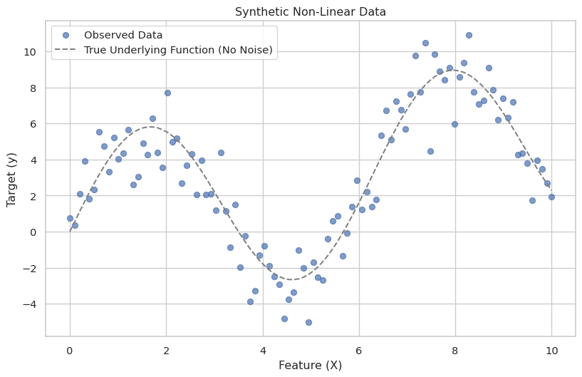

Synthetic Non-Linear Data (Sine Wave + Noise)

```python
# Generate X values
X = np.linspace(0, 10, 100)
# Generate y values based on a sine function plus random noise
y_true = np.sin(X) * 5 + X * 0.5 # Adding a slight upward trend too
noise = np.random.normal(0, 1.5, size=X.shape) # Add some noise
y = y_true + noise

# Reshape X for scikit-learn (it expects 2D arrays for features)
X = X.reshape(-1, 1)

# Plot the data
plt.figure(figsize=(10, 6))
plt.scatter(X, y, label='Observed Data', alpha=0.7)
plt.plot(X, y_true, color='gray', linestyle='--', label='True Underlying Function (No Noise)')
plt.xlabel('Feature (X)')
plt.ylabel('Target (y)')
plt.title('Synthetic Non-Linear Data')
plt.legend()
plt.show()
```

### 1. Standard Linear Regression (1st Order Polynomial)

Let’s first try fitting a standard linear regression model (a straight line) to this data and see how poorly it performs.

```
Linear Regression (1st Order):
R-squared: 0.111
Mean Squared Error: 12.836
```

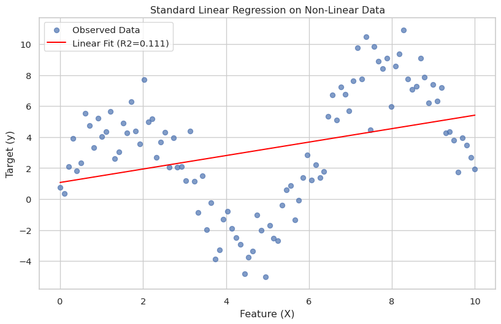

Standard Linear Regression Fit on Non-Linear Data

```python
# Initialize and fit the model
lin_reg = LinearRegression()
lin_reg.fit(X, y)

# Make predictions
y_pred_lin = lin_reg.predict(X)

# Calculate performance metrics
r2_lin = r2_score(y, y_pred_lin)
mse_lin = mean_squared_error(y, y_pred_lin)

print(f"Linear Regression (1st Order):")
print(f"R-squared: {r2_lin:.3f}")
print(f"Mean Squared Error: {mse_lin:.3f}")

# Plot the results
plt.figure(figsize=(10, 6))
plt.scatter(X, y, label='Observed Data', alpha=0.7)
plt.plot(X, y_pred_lin, color='red', label=f'Linear Fit (R2={r2_lin:.3f})')
plt.xlabel('Feature (X)')
plt.ylabel('Target (y)')
plt.title('Standard Linear Regression on Non-Linear Data')
plt.legend()
plt.show()
```

As expected, the straight line doesn’t capture the curve well. The R-squared is low, indicating the model explains little variance, and the MSE is high.

### 2. Polynomial Regression (2nd Order)

Now, let’s create a polynomial feature: $X^2$. We’ll fit a model of the form $y = \beta_0 + \beta_1 X + \beta_2 X^2$.

```
Polynomial Regression (2nd Order):
R-squared: 0.253
Mean Squared Error: 10.780
```

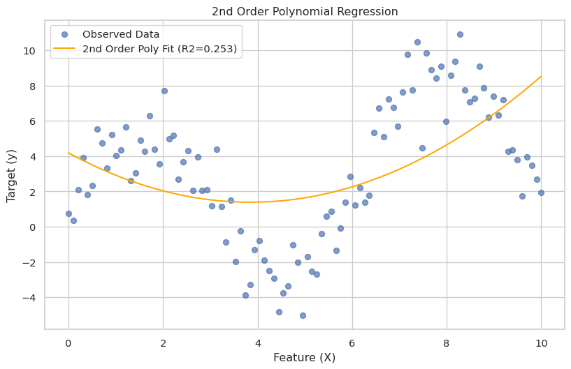

2nd Order Polynomial Regression Fit

```python
# Create polynomial features (degree 2)
poly_features_2 = PolynomialFeatures(degree=2, include_bias=False)
X_poly2 = poly_features_2.fit_transform(X)

# X_poly2 now contains the original X and X^2
# print(X_poly2.shape)
# print(X_poly2[:5]) # Show first 5 rows: [X, X^2]

# Initialize and fit the linear regression model on the transformed features
poly2_reg = LinearRegression()
poly2_reg.fit(X_poly2, y)

# Make predictions
y_pred_poly2 = poly2_reg.predict(X_poly2)

# Calculate performance metrics
r2_poly2 = r2_score(y, y_pred_poly2)
mse_poly2 = mean_squared_error(y, y_pred_poly2)

print(f"Polynomial Regression (2nd Order):")
print(f"R-squared: {r2_poly2:.3f}")
print(f"Mean Squared Error: {mse_poly2:.3f}")

# Plot the results
plt.figure(figsize=(10, 6))
plt.scatter(X, y, label='Observed Data', alpha=0.7)
# Sort values for plotting the curve smoothly
sort_axis = np.argsort(X.flatten())
plt.plot(X[sort_axis], y_pred_poly2[sort_axis], color='orange', label=f'2nd Order Poly Fit (R2={r2_poly2:.3f})')
plt.xlabel('Feature (X)')
plt.ylabel('Target (y)')
plt.title('2nd Order Polynomial Regression')
plt.legend()
plt.show()
```

The quadratic curve fits much better than the straight line, capturing some of the bend. R-squared has increased, and MSE has decreased.

### 3. Polynomial Regression (3rd Order)

Let’s try a 3rd order polynomial: $y = \beta_0 + \beta_1 X + \beta_2 X^2 + \beta_3 X^3$.

```
Polynomial Regression (3rd Order):
R-squared: 0.345
Mean Squared Error: 9.456
```

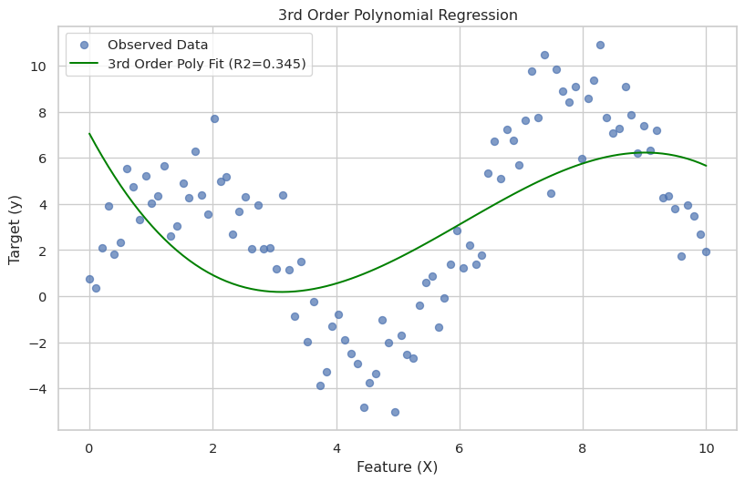

3rd Order Polynomial Regression Fit

```python
# Create polynomial features (degree 3)
poly_features_3 = PolynomialFeatures(degree=3, include_bias=False)
X_poly3 = poly_features_3.fit_transform(X)

# Initialize and fit the linear regression model
poly3_reg = LinearRegression()
poly3_reg.fit(X_poly3, y)

# Make predictions
y_pred_poly3 = poly3_reg.predict(X_poly3)

# Calculate performance metrics
r2_poly3 = r2_score(y, y_pred_poly3)
mse_poly3 = mean_squared_error(y, y_pred_poly3)

print(f"Polynomial Regression (3rd Order):")
print(f"R-squared: {r2_poly3:.3f}")
print(f"Mean Squared Error: {mse_poly3:.3f}")

# Plot the results
plt.figure(figsize=(10, 6))
plt.scatter(X, y, label='Observed Data', alpha=0.7)
sort_axis = np.argsort(X.flatten())
plt.plot(X[sort_axis], y_pred_poly3[sort_axis], color='green', label=f'3rd Order Poly Fit (R2={r2_poly3:.3f})')
plt.xlabel('Feature (X)')
plt.ylabel('Target (y)')
plt.title('3rd Order Polynomial Regression')
plt.legend()
plt.show()
```

The cubic curve fits even better, capturing more of the sine wave’s shape. R-squared is higher still, and MSE is lower. *Caution:* Using excessively high polynomial degrees can lead to overfitting, where the model fits the noise in the training data too closely and performs poorly on new data.

### 4. Sine Function Transformation

Since we know the underlying function involves a sine wave, let’s try transforming the feature using the `sin` function directly. We’ll fit a model like $y = \beta_0 + \beta_1 \sin(X)$. Note: In a real scenario, you might not know the exact function, but if you suspect periodicity, trigonometric transformations are worth trying. Sometimes combining polynomial and other terms (e.g., $y = \beta_0 + \beta_1 X + \beta_2 \sin(X)$) is effective. For this example, we’ll use just the sine feature.

```
Sine Transformation Regression:
R-squared: 0.714
Mean Squared Error: 4.126
```

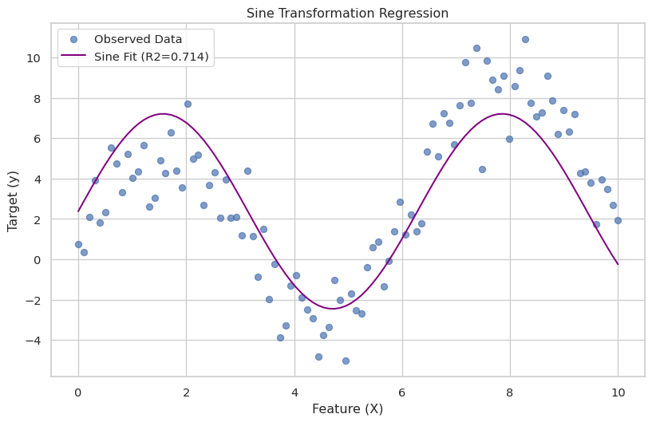

Sine Transformation Regression Fit

```python
# We can create the transformed feature manually or use FunctionTransformer
# Manual approach:
X_sin = np.sin(X)

# If combining with linear term: X_combined = np.hstack((X, X_sin))

# Fit linear regression on the sine-transformed feature
sin_reg = LinearRegression()
sin_reg.fit(X_sin, y) # Fit y against sin(X)

# Make predictions
y_pred_sin = sin_reg.predict(X_sin)

# Calculate performance metrics
r2_sin = r2_score(y, y_pred_sin)
mse_sin = mean_squared_error(y, y_pred_sin)

print(f"Sine Transformation Regression:")
print(f"R-squared: {r2_sin:.3f}")
print(f"Mean Squared Error: {mse_sin:.3f}")

# Plot the results
plt.figure(figsize=(10, 6))
plt.scatter(X, y, label='Observed Data', alpha=0.7)
sort_axis = np.argsort(X.flatten()) # Need to sort X to plot the curve correctly
plt.plot(X[sort_axis], y_pred_sin[sort_axis], color='purple', label=f'Sine Fit (R2={r2_sin:.3f})')
plt.xlabel('Feature (X)')
plt.ylabel('Target (y)')
plt.title('Sine Transformation Regression')
plt.legend()
plt.show()
```

This sine transformation captures the cyclical nature well, although it misses the slight upward trend we added (because we didn’t include the original `X` term in this specific model). Comparing the R-squared and MSE values shows how different transformations impact model fit.

### Comparing Models

Let’s plot all the fits together for comparison.

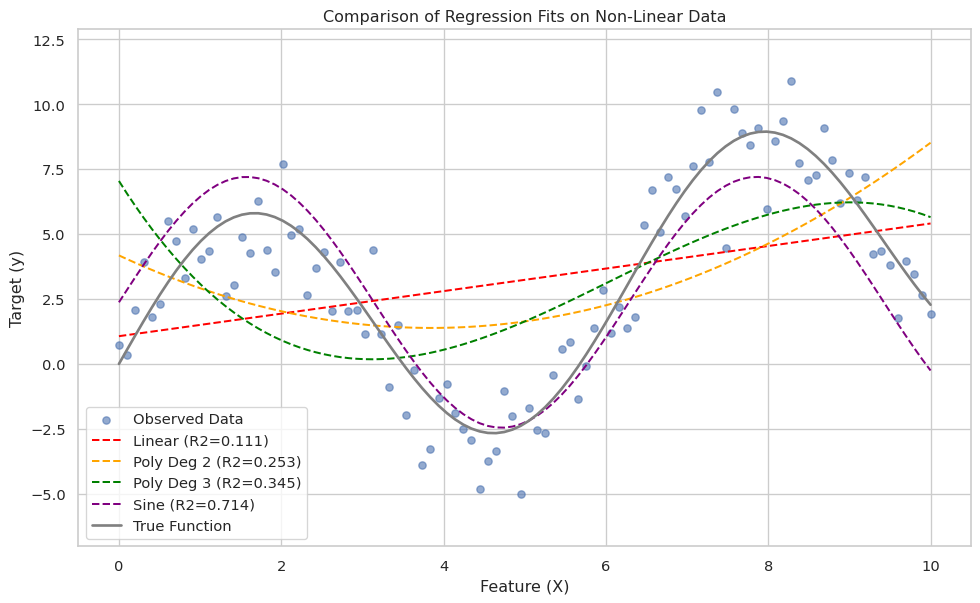

Comparison of Regression Fits

```python
plt.figure(figsize=(12, 7))
plt.scatter(X, y, label='Observed Data', alpha=0.6, s=30)
sort_axis = np.argsort(X.flatten())

# Plot fits
plt.plot(X[sort_axis], y_pred_lin[sort_axis], color='red', linestyle='--', label=f'Linear (R2={r2_lin:.3f})')
plt.plot(X[sort_axis], y_pred_poly2[sort_axis], color='orange', linestyle='--', label=f'Poly Deg 2 (R2={r2_poly2:.3f})')
plt.plot(X[sort_axis], y_pred_poly3[sort_axis], color='green', linestyle='--', label=f'Poly Deg 3 (R2={r2_poly3:.3f})')
plt.plot(X[sort_axis], y_pred_sin[sort_axis], color='purple', linestyle='--', label=f'Sine (R2={r2_sin:.3f})')
plt.plot(X[sort_axis], y_true[sort_axis], color='gray', linestyle='-', linewidth=2, label='True Function')


plt.xlabel('Feature (X)')
plt.ylabel('Target (y)')
plt.title('Comparison of Regression Fits on Non-Linear Data')
plt.legend()
plt.ylim(min(y) - 2, max(y) + 2) # Adjust ylim for better visualization
plt.show()
```

This comparison clearly illustrates how transforming features allows linear regression models to capture complex, non-linear patterns effectively. The choice of transformation depends on the suspected underlying relationship in the data.

## Part 2: Multi-Class Classification & Evaluation

Now let’s switch gears to classification. Many business problems involve predicting a category from more than two options. Examples include:

- **Customer Segmentation:** Classifying customers into ‘Bronze’, ‘Silver’, ‘Gold’ tiers.
- **Product Category Prediction:** Assigning a product to ‘Electronics’, ‘Apparel’, ‘Home Goods’.
- **Sentiment Analysis:** Categorizing reviews as ‘Positive’, ‘Neutral’, ‘Negative’.
- **Churn Risk:** Assessing customer churn risk as ‘Low’, ‘Medium’, ‘High’.

We’ll use Logistic Regression, which can be extended to handle multi-class problems (often using strategies like One-vs-Rest or Multinomial). Our focus will be on evaluating the performance of such a model.

### Business Case: Customer Service Tier Prediction

Imagine a telecom company wants to predict the service tier (‘Basic’, ‘Premium’, ‘Enterprise’) a new business customer is likely to sign up for based on their company size (number of employees) and estimated monthly data usage (in GB). This helps the sales team tailor their initial offers.

### Generating Synthetic Multi-Class Data

Let’s generate some synthetic data for this scenario.

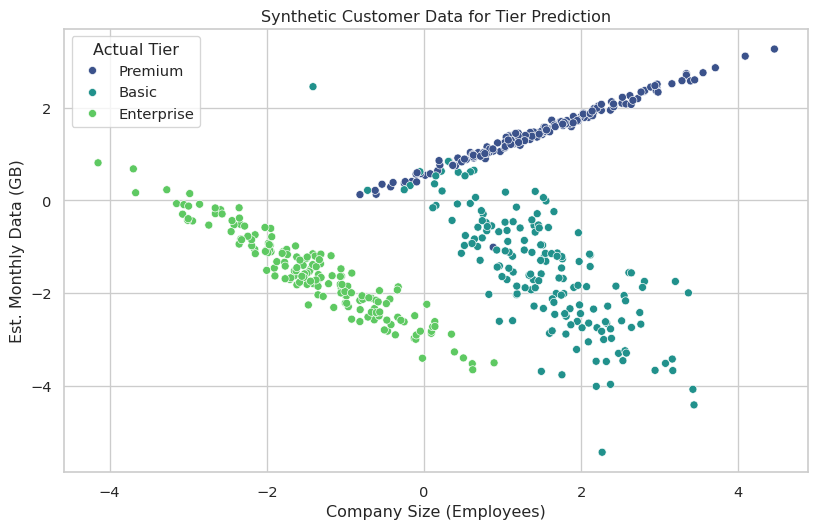

Synthetic Customer Tier Data

```
   Company Size (Employees)  Est. Monthly Data (GB) Target Tier
0                  1.527917                1.582279     Premium
1                  1.906849               -1.878083       Basic
2                  2.019133                1.856495     Premium
3                 -1.336896               -1.685549  Enterprise
4                 -2.149242               -0.741277  Enterprise

Class Distribution:
Target Tier
Premium       167
Enterprise    167
Basic         166
Name: count, dtype: int64
```

```python
# Generate synthetic data for 3 classes
n_samples = 500
X_clf, y_clf = make_classification(n_samples=n_samples, n_features=2, n_informative=2, n_redundant=0,
                               n_clusters_per_class=1, n_classes=3, random_state=42, class_sep=1.5)

# Give features business context names
feature_names = ['Company Size (Employees)', 'Est. Monthly Data (GB)']
df_clf = pd.DataFrame(X_clf, columns=feature_names)

# Map numeric classes (0, 1, 2) to business context names
class_names = ['Basic', 'Premium', 'Enterprise']
df_clf['Target Tier'] = pd.Series(y_clf).map({0: class_names[0], 1: class_names[1], 2: class_names[2]})

# Visualize the data
plt.figure(figsize=(10, 6))
sns.scatterplot(data=df_clf, x=feature_names[0], y=feature_names[1], hue='Target Tier', palette='viridis')
plt.title('Synthetic Customer Data for Tier Prediction')
plt.xlabel(feature_names[0])
plt.ylabel(feature_names[1])
plt.legend(title='Actual Tier')
plt.show()

# Display first few rows
print(df_clf.head())
print("\nClass Distribution:")
print(df_clf['Target Tier'].value_counts())
```

We have data points representing customers, colored by their actual service tier. There’s some overlap, making the classification task non-trivial.

### Training a Multi-Class Logistic Regression Model

We’ll split the data into training and testing sets and train a Logistic Regression model. We use `multi_class='ovr'` (One-vs-Rest), which trains a separate binary classifier for each class against all other classes.

```python
# Features (X) and Target (y)
X_features = df_clf[feature_names]
y_target = df_clf['Target Tier']

# Split data into training and testing sets
X_train, X_test, y_train, y_test = train_test_split(X_features, y_target, test_size=0.3, random_state=42, stratify=y_target) # Stratify ensures class proportions are similar in train/test

print(f"Training set size: {X_train.shape[0]}")
print(f"Test set size: {X_test.shape[0]}")

# Initialize and train the Logistic Regression model
# 'ovr' trains one binary classifier per class
# 'liblinear' solver works well for smaller datasets and 'ovr'
log_reg_multi = LogisticRegression(multi_class='ovr', solver='liblinear', random_state=42)
log_reg_multi.fit(X_train, y_train)

# Make predictions on the test set
y_pred = log_reg_multi.predict(X_test)

# Get predicted probabilities (needed for PR curve later)
# Returns probabilities for each class [class0_prob, class1_prob, class2_prob]
y_prob = log_reg_multi.predict_proba(X_test)

print("\nSample Predictions vs Actual:")
print(pd.DataFrame({'Actual': y_test[:5], 'Predicted': y_pred[:5]}))
```

[output not shown]

```
Training set size: 350
Test set size: 150

Sample Predictions vs Actual:
         Actual   Predicted
3    Enterprise  Enterprise
484     Premium     Premium
271       Basic       Basic
183  Enterprise  Enterprise
384       Basic       Basic
```

### Evaluating with a Multi-Class Confusion Matrix

A confusion matrix is essential for understanding *how* a classifier is performing for each class. It shows the counts of correct and incorrect predictions broken down by class.

- **Rows:** Actual (True) Classes
- **Columns:** Predicted Classes
- **Diagonal:** Correct predictions (True Positives for each class, conceptually)
- **Off-Diagonal:** Misclassifications (False Positives and False Negatives)

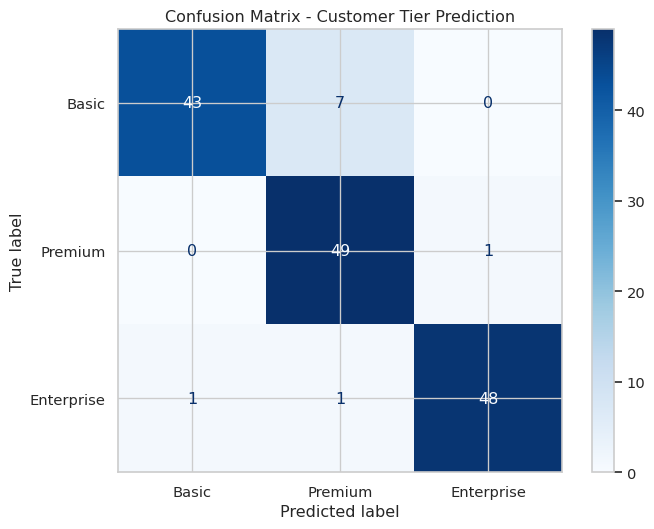

Confusion Matrix for Customer Tier Prediction

```
Classification Report:
              precision    recall  f1-score   support

       Basic       0.98      0.86      0.91        50
     Premium       0.98      0.96      0.97        50
  Enterprise       0.86      0.98      0.92        50

    accuracy                           0.93       150
   macro avg       0.94      0.93      0.93       150
weighted avg       0.94      0.93      0.93       150
```

```python
# Generate the confusion matrix
cm = confusion_matrix(y_test, y_pred, labels=class_names)

# Display the confusion matrix using ConfusionMatrixDisplay for better visualization
disp = ConfusionMatrixDisplay(confusion_matrix=cm, display_labels=class_names)

fig, ax = plt.subplots(figsize=(8, 6))
disp.plot(ax=ax, cmap='Blues', values_format='d') # 'd' format for integers
plt.title('Confusion Matrix - Customer Tier Prediction')
plt.show()

# Print classification report for detailed metrics (precision, recall, F1-score per class)
print("\nClassification Report:")
print(classification_report(y_test, y_pred, target_names=class_names))
```

**Interpreting the Matrix:**

- The diagonal values (e.g., top-left for ‘Basic’, middle for ‘Premium’, bottom-right for ‘Enterprise’) show the number of customers correctly classified into each tier.
- Off-diagonal values show errors. For example, the value in row ‘Basic’, column ‘Premium’ indicates how many actual ‘Basic’ customers were incorrectly predicted as ‘Premium’.
- The `classification_report` gives us precision, recall, and F1-score for each class, along with overall accuracy and averages. This helps identify if the model struggles more with specific classes. For instance, look for classes with lower precision (many false positives) or lower recall (many false negatives).

## Conclusion

Today we explored two important concepts:

1. **Feature Transformations:** We saw how polynomial and other transformations allow linear regression models to capture non-linear relationships in data, often significantly improving model fit compared to a standard linear approach. Remember to be mindful of overfitting when using high-degree polynomials.
2. **Multi-Class Evaluation:** We built a multi-class logistic regression model for a customer tier prediction scenario. We learned to interpret the multi-class confusion matrix to understand class-specific errors and used the classification report for detailed metrics.

These techniques provide more flexibility in modeling complex data and offer deeper insights into classifier performance beyond simple accuracy. Keep practicing applying these concepts to different business problems!